# Kan_Analysis

Marton Kovacs

28 September, 2020

# Load packages

```r
library(tidyverse)
library(osfr)
library(readxl)
library(readbulk)
library(ez)
library(psych)
```

# Load custom functions

```r
source("utils.R")
```

# Exp1

## Outcome neutral test

### Test sentence reading time

#### Import data

```r
outcome_neutral_sentence_data <- read_tsv("Data/Processed/Exp1/Kan_Processed_Exp1_OutcomeNeutral_Sentence_data.tsv")
```

#### Nest the data

```r
outcome_neutral_sentence_data <-
  outcome_neutral_sentence_data %>%
  nest(data = c(participant_id, Congruent, Incongruent))
```

#### Performing the t-tests

We calculate the t test for each sentence region separately.

```r
outcome_neutral_sentence_data <-
  outcome_neutral_sentence_data %>%
  mutate(t_value = map_dbl(data,
                       ~ t.test(.$Incongruent, .$Congruent, paired = TRUE, alternative = "greater") %>%
                         broom::tidy() %>%
                         pull(statistic)),
         df = map_dbl(data,
                       ~ t.test(.$Incongruent, .$Congruent, paired = TRUE, alternative = "greater") %>%
                         broom::tidy() %>%
                         pull(parameter)),
         p_value = map_dbl(data,
                       ~ t.test(.$Incongruent, .$Congruent, paired = TRUE, alternative = "greater") %>%
                         broom::tidy() %>%
                         pull(p.value)),
         raw_effect = map_dbl(data,
                       ~ t.test(.$Incongruent, .$Congruent, paired = TRUE, alternative = "greater") %>%
                         broom::tidy() %>%
                         pull(estimate)))
```

#### Calculating the SE

```r
outcome_neutral_sentence_data <-
  outcome_neutral_sentence_data %>%
  mutate(se = map2_dbl(raw_effect, t_value,
                       ~ abs(.x / .y)))
```

#### Calculating the Bayes factor

We are calculating the Bf for all the regions, but our main interest is the the temporarily ambiguous and disambiguating region.

Checking the number of observations for each sentence region.

```r
map(outcome_neutral_sentence_data$data, nrow)
```

```
## [[1]]
## [1] 133
##
## [[2]]
## [1] 133
##
## [[3]]
## [1] 133
##
## [[4]]
## [1] 133
##
## [[5]]
## [1] 133
##
## [[6]]
## [1] 133
##
## [[7]]
## [1] 133
```

Creating a plots to visualize the difference.

We are creating a plot function for visualization.

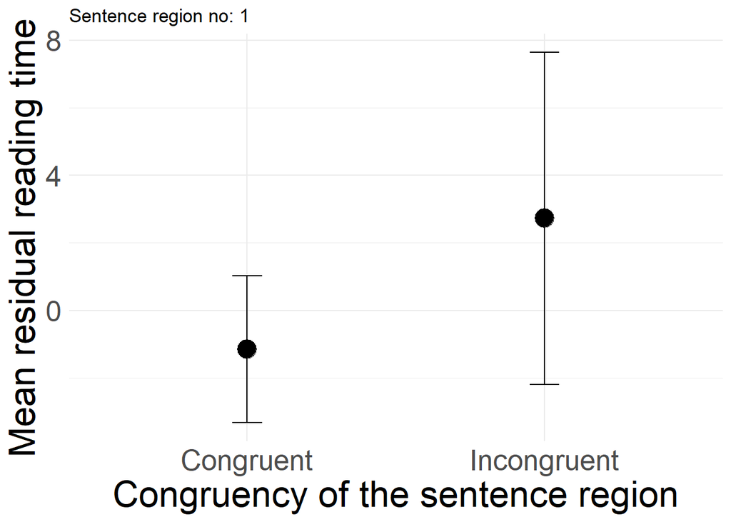

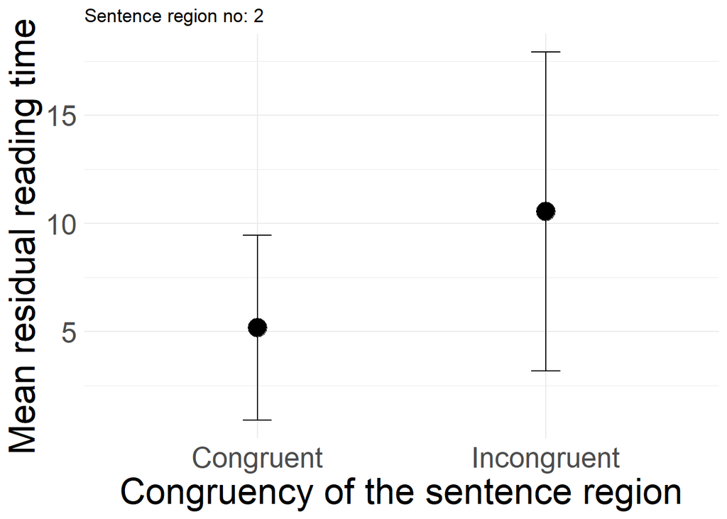

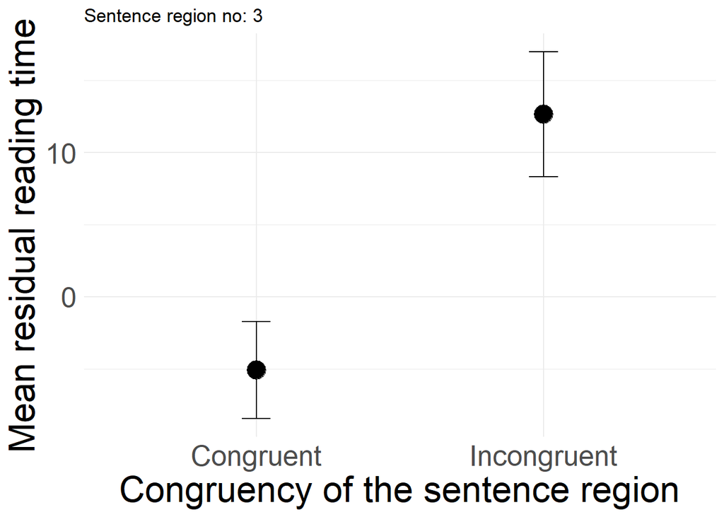

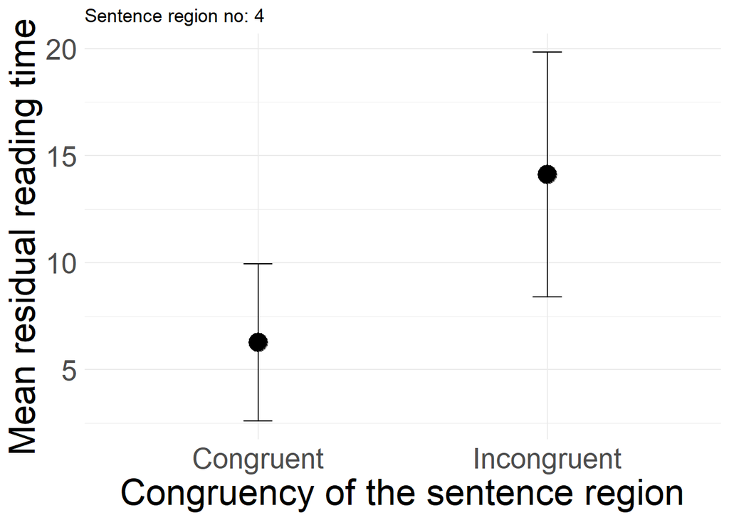

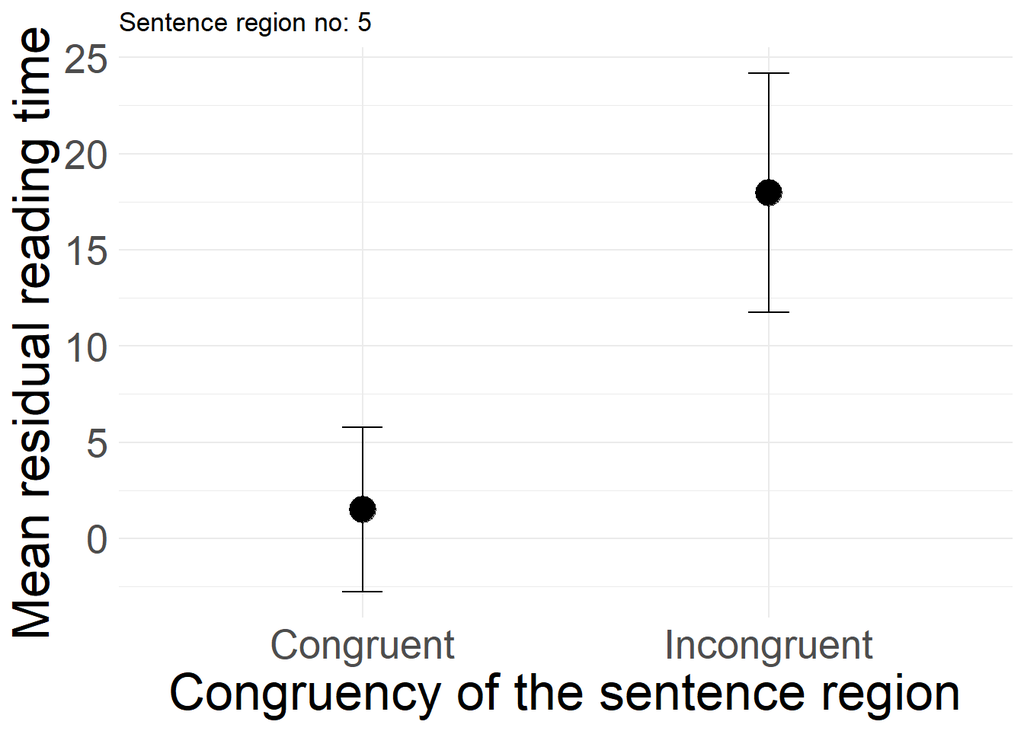

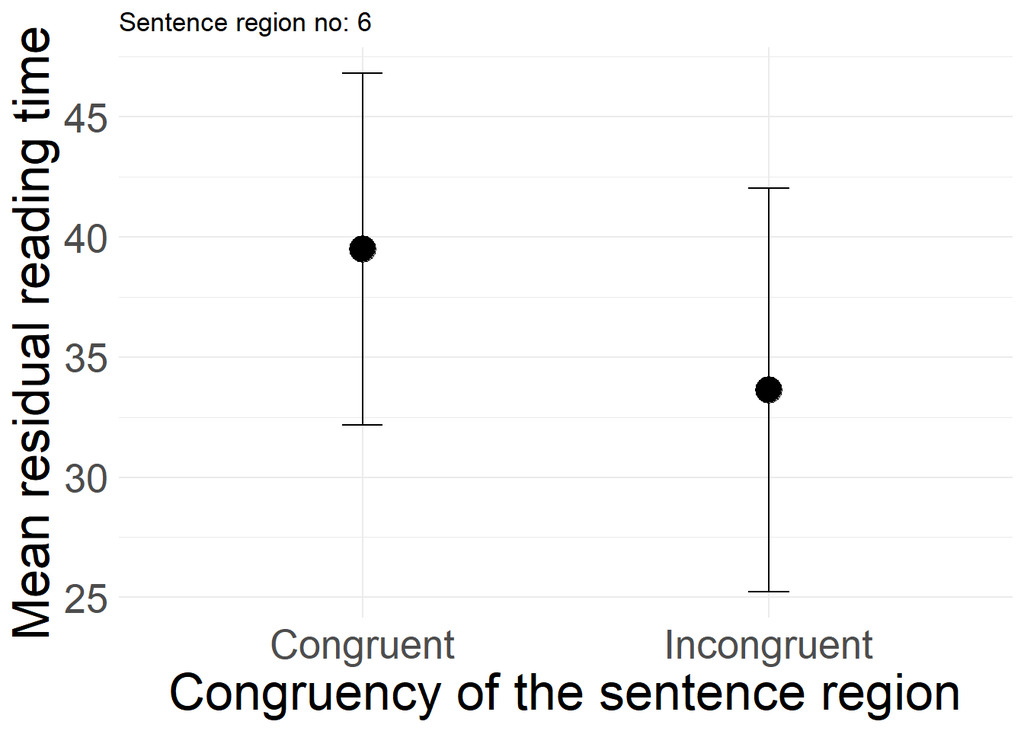

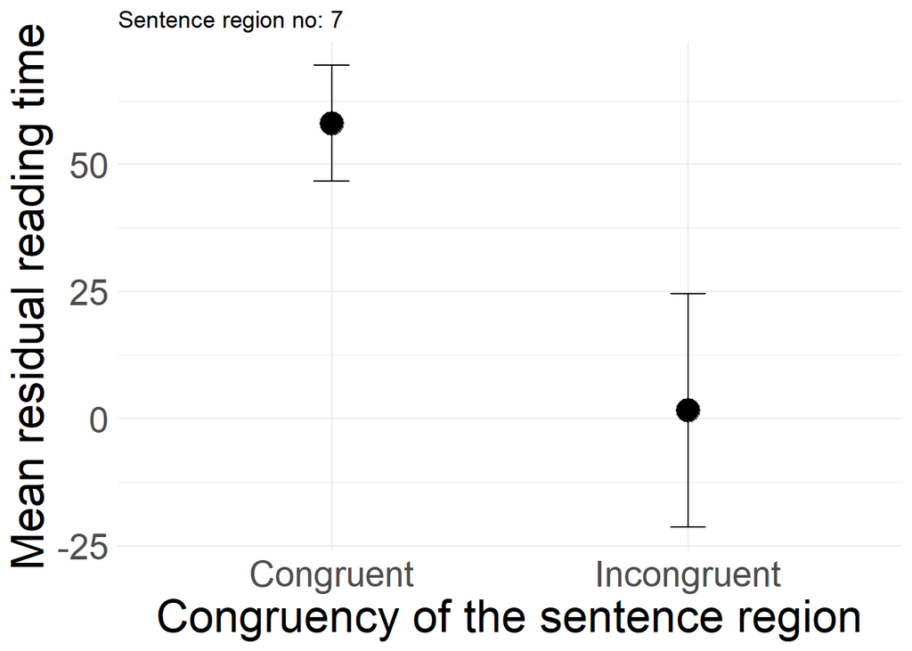

```r
sentence_region_plot <- function(df, name) {
  df %>%
  select(Congruent, Incongruent) %>%
  gather(key = "congruency", value = "resid_mean_reading_time") %>%
  group_by(congruency) %>%
  summarise(n = n(),
            mean = mean(resid_mean_reading_time),
            sd = sd(resid_mean_reading_time, na.rm = T),
            se = sd / sqrt(n)) %>%
  ggplot() +
  aes(x = congruency,
      y = mean) +
  geom_point(size = 6) +
  geom_errorbar(aes(ymin = mean - (se * 1.96),
                    ymax = mean + (se  * 1.96)),
                width = .1) +
  labs(title = paste("Sentence region no:", name),
       x = "Congruency of the sentence region",
       y = "Mean residual reading time") +
  theme_minimal() +
  theme(axis.title = element_text(size = 25),
        axis.text = element_text(size = 20),
        strip.text.x = element_text(size = 20))
}

outcome_neutral_sentence_data <-
  outcome_neutral_sentence_data %>%
  mutate(sentence_plot = map2(data, as.character(sentence_region_no),
                     ~ sentence_region_plot(.x, .y)))
outcome_neutral_sentence_data$sentence_plot
```

Assigning SD theory for the Bayes factor analysis.

```r
outcome_neutral_sentence_data <-
  outcome_neutral_sentence_data %>%
  mutate(sd_theory = case_when(sentence_region_no == 3 ~ 40L,
                               sentence_region_no == 4 ~ 18L,
                               TRUE ~ 18L))
```

Running the Bf analysis for all sentence regions.

```r
outcome_neutral_sentence_data <-
  outcome_neutral_sentence_data %>%
  mutate(bf = pmap_dbl(list(se, raw_effect, df, sd_theory),
                       ~ Bf(sd = ..1,
                            obtained = ..2,
                            dfdata = ..3,
                            meanoftheory = 0,
                            sdtheory = ..4,
                            dftheory = 10^10,
                            tail = 1)))
```

## Crucial tests

### Reaction time analysis

#### Import data

```r
main_analysis_rt_data <- vroom::vroom("Data/Processed/Exp1/Kan_Processed_Exp1_Main_Rt_data.tsv")
```

```
## Rows: 4,738
## Columns: 16
## chr [ 4]: lab, stim_type, stimulus, stim_color
## dbl [12]: participant_id, trial_id, response_time, is_previous_congruent, is_congruent, is...
##
## Pass a specification to the `col_types` argument to quiet this message
```

#### Exploratory data analysis

The number of response per participant.

```r
main_analysis_rt_data %>%
  count(participant_id)
```

```
## # A tibble: 132 x 2
##    participant_id     n
##             <dbl> <int>
##  1            109    32
##  2           1010    34
##  3           1012    42
##  4           1013    40
##  5           1014    30
##  6           1015    30
##  7           1016    36
##  8           1017    37
##  9           1018    14
## 10           1021    32
## # ... with 122 more rows
```

The number of participants.

```r
main_analysis_rt_data %>%
  distinct(participant_id) %>%
  count()
```

```
## # A tibble: 1 x 1
##       n
##   <int>
## 1   132
```

#### Figures

The congruency sequence effect for the reaction time responses.

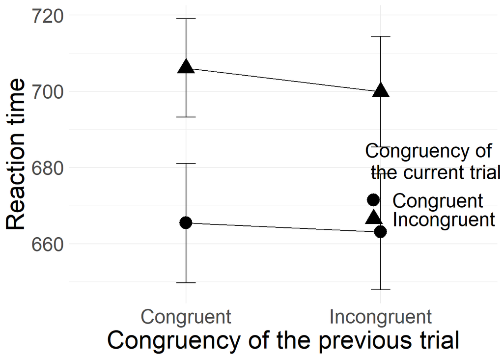

```r
main_analysis_rt_data %>%
  mutate(is_previous_congruent = case_when(is_previous_congruent ==  0L ~ "Incongruent",
                                           is_previous_congruent ==  1L ~ "Congruent"),
         is_congruent = case_when(is_congruent ==  0L ~ "Incongruent",
                                  is_congruent ==  1L ~ "Congruent")) %>%
  group_by(participant_id, is_previous_congruent, is_congruent) %>%
  summarise(participant_mean_rt = mean(response_time, na.rm = T)) %>%
  group_by(is_previous_congruent, is_congruent) %>%
  summarise(N = n(),
            mean_rt = mean(participant_mean_rt, na.rm = T),
            sd_rt = sd(participant_mean_rt, na.rm = T),
            se_rt = sd_rt / sqrt(N)) %>%
  ggplot() +
  aes(x = is_previous_congruent,
      y = mean_rt,
      shape = is_congruent,
      group = is_congruent) +
  geom_path() +
  geom_point(size = 6) +
  geom_errorbar(aes(ymin = mean_rt - (se_rt * 1.96),
                    ymax = mean_rt + (se_rt * 1.96)),
                width = .1) +
  guides(color = FALSE) +
  xlab("Congruency of the previous trial")+
  ylab("Reaction time") +
  guides(shape = guide_legend(title = "Congruency of \n the current trial")) +
  theme_minimal() +
  theme(axis.title = element_text(size = 25),
        axis.text = element_text(size = 20),
        legend.text = element_text(size = 20),
        legend.title = element_text(size = 20),
        legend.position = c(.85, .4))
```

Saving the figure.

```r
ggsave("Figures/Kan_Exp1_Rt_Congruency_Plot.png", width = 14.4, height = 8, plot = last_plot())
```

#### Data preprocessing

We are calculating the mean reaction time per participant per condition (ci, ic, cc, ii).

```r
main_analysis_rt_aggregate <-
  main_analysis_rt_data %>%
  group_by(participant_id, is_congruent, is_previous_congruent) %>%
  summarise(rt_conditional_mean = mean(response_time, na.rm = T)) %>%
  ungroup() %>%
  mutate(is_congruent = as.factor(is_congruent),
         is_previous_congruent = as.factor(is_previous_congruent),
         participant_id = as.factor(participant_id))
```

The number of conditions per participant. Because we excluded the incorrect trials, it can happen that a participant does no have reaction time responses from all the 4 conditions.

```r
main_analysis_rt_aggregate %>%
  count(participant_id) %>%
  arrange(n)
```

```
## # A tibble: 132 x 2
##    participant_id     n
##    <fct>          <int>
##  1 109                4
##  2 1010               4
##  3 1012               4
##  4 1013               4
##  5 1014               4
##  6 1015               4
##  7 1016               4
##  8 1017               4
##  9 1018               4
## 10 1021               4
## # ... with 122 more rows
```

Save the [participant_id] of those participants who do not have data from all the four conditions.

```r
missing_condition <-
  main_analysis_rt_aggregate %>%
  count(participant_id) %>%
  filter(n != 4) %>%
  select(participant_id)
```

The number of participants who has missing conditions.

```r
nrow(missing_condition)
```

```
## [1] 0
```

Excluding these participants from further analysis.

```r
main_analysis_rt_aggregate <-
  main_analysis_rt_aggregate %>%
  anti_join(., missing_condition, by = "participant_id")
```

Calculating the raw congruency, previous congruency and interaction effect for each participant.

```r
main_analysis_rt_raw_effect <-
  main_analysis_rt_aggregate %>%
  ungroup() %>%
  mutate(condition = case_when(is_previous_congruent == 0L & is_congruent == 0L ~ "ii",
                               is_previous_congruent == 0L & is_congruent == 1L ~ "ic",
                               is_previous_congruent == 1L & is_congruent == 0L ~ "ci",
                               is_previous_congruent == 1L & is_congruent == 1L ~ "cc",
                               TRUE ~ NA_character_)) %>%
  select(-is_previous_congruent, -is_congruent) %>%
  spread(key = condition, value = rt_conditional_mean) %>%
  mutate(congruency_effect = ((ci + ii) / 2) - ((cc + ic) / 2),
         previous_congruency_effect = ((ci + cc) / 2) - ((ii + ic) / 2),
         interaction_effect = (ci - cc) - (ii - ic))
```

Running the repeated measure ANOVA.

```r
anova_rt <-
  aov(rt_conditional_mean ~ is_congruent * is_previous_congruent + Error(participant_id / (is_congruent * is_previous_congruent)), data = main_analysis_rt_aggregate)
```

Saving the F value and Df for each effect of interest.

```r
anova_rt_f_value <-
  anova_rt %>%
  broom::tidy() %>%
  select(term, statistic) %>%
  transmute(term = case_when(term == "is_congruent" ~ "main_effect_congruent",
                             term == "is_previous_congruent" ~ "main_effect_previous_congruent",
                             term == "is_congruent:is_previous_congruent" ~ "interaction_effect",
                             term == "Residuals" ~ term),
            f_value = statistic) %>%
  filter(!is.na(f_value))
```

Calculating the raw effects summarized for every participant.

```r
main_analysis_rt_raw_effect <-
  main_analysis_rt_raw_effect %>%
  summarise(main_effect_congruent = mean(congruency_effect, na.rm = T),
            main_effect_previous_congruent = mean(previous_congruency_effect, na.rm = T),
            interaction_effect = mean(interaction_effect, na.rm = T),
            n_participant = n()) %>%
  gather(key = "term", value = "raw_effect", -n_participant)
```

Joining the calculated F values and Dfs with the raw effects.

```r
main_analysis_rt_raw_effect <-
  main_analysis_rt_raw_effect %>%
  inner_join(., anova_rt_f_value, by = "term")
```

Calculating the SE from the raw effect and the F value.

```r
main_analysis_rt_raw_effect <-
  main_analysis_rt_raw_effect %>%
  mutate(se = abs(raw_effect / sqrt(f_value)))
```

#### Running the analysis

Saving the values needed for the analysis.

```r
# Obtained sd
interaction_se <-
  main_analysis_rt_raw_effect %>%
  filter(term == "interaction_effect") %>%
  pull(se)

# Obtained effect
interaction_effect <-
  main_analysis_rt_raw_effect %>%
  filter(term == "interaction_effect") %>%
  pull(raw_effect)

# Df
interaction_df <-
  main_analysis_rt_raw_effect %>%
  filter(term == "interaction_effect") %>%
  pull(n_participant)
```

Running the Bf analysis with the model described in the paper.

```r
Bf(sd = interaction_se,
   obtained = interaction_effect,
   dfdata = interaction_df - 1,
   meanoftheory = 0,
   sdtheory = 30,
   dftheory = 10^10,
   tail = 1)
```

```
## [1] 0.3655853
```

#### Test Stroop effect

This is an outcome neutral test, therefore, the results of this test do not effect our main conclusions.

Saving the values needed for the analysis.

```r
# Obtained sd
main_se <-
  main_analysis_rt_raw_effect %>%
  filter(term == "main_effect_congruent") %>%
  pull(se)

# Obtained effect
main_effect <-
  main_analysis_rt_raw_effect %>%
  filter(term == "main_effect_congruent") %>%
  pull(raw_effect)

# Df
main_df <-
  main_analysis_rt_raw_effect %>%
  filter(term == "main_effect_congruent") %>%
  pull(n_participant)
```

Running the Bf analysis with the model described in the paper.

```r
Bf(sd = main_se,
   obtained = main_effect,
   dfdata = main_df - 1,
   meanoftheory = 0,
   sdtheory = 28,
   dftheory = 10^10,
   tail = 1)
```

```
## [1] 4.613872e+13
```

### Accuracy analysis

#### Import data

```r
main_analysis_acc_data <-
  read_tsv("Data/Processed/Exp1/Kan_Processed_Exp1_Main_Acc_data.tsv")
```

#### Exploratory data analysis

The number of response per participant.

```r
main_analysis_acc_data %>%
  group_by(participant_id) %>%
  count()
```

```
## # A tibble: 132 x 2
## # Groups:   participant_id [132]
##    participant_id     n
##             <dbl> <int>
##  1            109    42
##  2           1010    42
##  3           1012    42
##  4           1013    42
##  5           1014    42
##  6           1015    42
##  7           1016    42
##  8           1017    42
##  9           1018    42
## 10           1021    42
## # ... with 122 more rows
```

The number of participants.

```r
main_analysis_acc_data %>%
  distinct(participant_id) %>%
  count()
```

```
## # A tibble: 1 x 1
##       n
##   <int>
## 1   132
```

#### The distribution of hit rates

Calculating the hit rate for each participant.

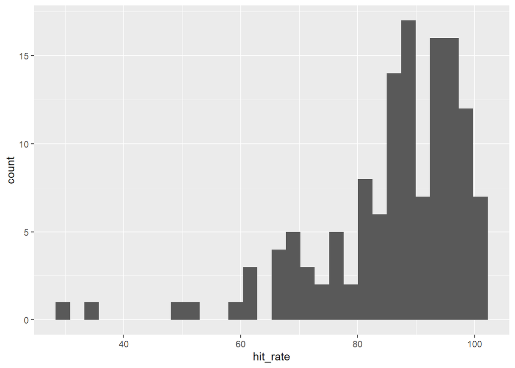

```r
main_analysis_acc_data %>%
  group_by(participant_id) %>%
  summarise(acc = mean(is_correct),
            hit_rate = acc * 100) %>%
  arrange(acc) %>%
  ggplot() +
  aes(x = hit_rate) %>%
  geom_histogram()
```

#### Figures

The congruency sequency effect for the accuracy responses.

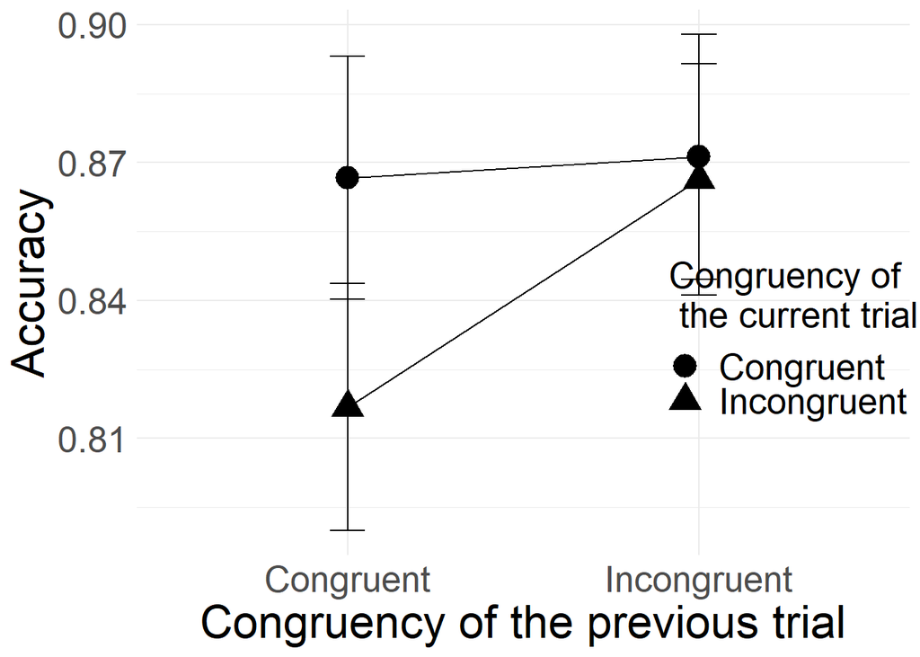

```r
main_analysis_acc_data %>%
  mutate(is_previous_congruent = case_when(is_previous_congruent ==  0L ~ "Incongruent",
                                           is_previous_congruent ==  1L ~ "Congruent"),
         is_congruent = case_when(is_congruent ==  0L ~ "Incongruent",
                                  is_congruent ==  1L ~ "Congruent")) %>%
  group_by(participant_id, is_previous_congruent, is_congruent) %>%
  summarise(participant_mean_acc = mean(is_correct, na.rm = T)) %>%
  group_by(is_previous_congruent, is_congruent) %>%
  summarise(N = n(),
            mean_acc = mean(participant_mean_acc, na.rm = T),
            sd_acc = sd(participant_mean_acc, na.rm = T),
            se_acc = sd_acc / sqrt(N)) %>%
  ggplot() +
  aes(x = is_previous_congruent,
      y = mean_acc,
      shape = is_congruent,
      group = is_congruent) +
  geom_path() +
  geom_point(size = 6) +
  geom_errorbar(aes(ymin = mean_acc - (se_acc * 1.96),
                    ymax = mean_acc + (se_acc * 1.96)),
                width = .1) +
  guides(color = FALSE) +
  xlab("Congruency of the previous trial")+
  ylab("Accuracy") +
  guides(shape = guide_legend(title = "Congruency of \n the current trial")) +
  theme_minimal() +
  theme(axis.title = element_text(size = 25),
        axis.text = element_text(size = 20),
        legend.text = element_text(size = 20),
        legend.title = element_text(size = 20),
        legend.position = c(.85, .4))
```

Saving the figure.

```r
ggsave("Figures/Kan_Exp1_Acc_Congruency_Plot.png", width = 14.4, height = 8, plot = last_plot())
```

#### Data preprocessing

We are calculating the accuracy for each condition (cc, ci, ic, ii) for each participant.

```r
main_analysis_acc_aggregate <-
  main_analysis_acc_data %>%
  group_by(participant_id, is_congruent, is_previous_congruent) %>%
  summarise(acc_conditional_mean = mean(is_correct, na.rm = T)) %>%
  ungroup()
```

We convert the predictor variables for the ANOVA to factors.

```r
main_analysis_acc_aggregate <-
  main_analysis_acc_aggregate %>%
  mutate(is_congruent = as_factor(is_congruent),
         is_previous_congruent = as_factor(is_previous_congruent),
         participant_id = as_factor(participant_id))
```

We are running the ANOVA described in the paper.

```r
anova_acc <-
  ezANOVA(data = main_analysis_acc_aggregate, dv = acc_conditional_mean, wid = participant_id, within = .(is_congruent, is_previous_congruent), type = 3)
```

We are converting the output of the ANOVA to tibble format.

```r
anova_acc <-
  as_tibble(anova_acc$ANOVA)
```

We are extracting the F value and the df for each term in the ANOVA.

```r
anova_acc_f_value <-
  anova_acc %>%
  filter(Effect %in% c("is_congruent",
                       "is_previous_congruent",
                       "is_congruent:is_previous_congruent")) %>%
  transmute(term = case_when(Effect == "is_congruent" ~ "main_effect_congruent",
                             Effect == "is_previous_congruent" ~ "main_effect_previous_congruent",
                             Effect == "is_congruent:is_previous_congruent" ~ "interaction_effect"),
            f_value = F,
            df = DFd)
```

We caluclate the raw effects for each term for each participant.

```r
main_analysis_acc_participant_level_raw_effect <-
  main_analysis_acc_aggregate %>%
  ungroup() %>%
  mutate(condition = case_when(is_previous_congruent == 0L & is_congruent == 0L ~ "ii",
                               is_previous_congruent == 0L & is_congruent == 1L ~ "ic",
                               is_previous_congruent == 1L & is_congruent == 0L ~ "ci",
                               is_previous_congruent == 1L & is_congruent == 1L ~ "cc",
                               TRUE ~ NA_character_)) %>%
  select(-is_previous_congruent, -is_congruent) %>%
  spread(key = condition, value = acc_conditional_mean) %>%
  mutate(congruency_effect =  ((cc + ic) / 2) - ((ci + ii) / 2),
         previous_congruency_effect = ((ci + cc) / 2) - ((ii + ic) / 2),
         interaction_effect = (cc - ci) - (ic - ii))
```

We are aggregating the raw effects of the participants.

```r
main_analysis_acc_raw_effect <-
  main_analysis_acc_participant_level_raw_effect %>%
  summarise(main_effect_congruent = mean(congruency_effect, na.rm = T),
            main_effect_previous_congruent = mean(previous_congruency_effect, na.rm = T),
            interaction_effect = mean(interaction_effect, na.rm = T)) %>%
  gather(key = "term", value = "raw_effect")
```

We join the F value and Dfs to the raw effects for each term.

```r
main_analysis_acc_raw_effect <-
  main_analysis_acc_raw_effect %>%
  inner_join(., anova_acc_f_value, by = "term")
```

From the raw effect and the F value we calculate the SE.

```r
main_analysis_acc_raw_effect <-
  main_analysis_acc_raw_effect %>%
  mutate(se = abs(raw_effect / sqrt(f_value)))
```

#### Running the analysis

Saving the values needed for the analysis.

```r
# Obtained sd
interaction_se <-
  main_analysis_acc_raw_effect %>%
  filter(term == "interaction_effect") %>%
  pull(se)

# Obtained effect
interaction_effect <-
  main_analysis_acc_raw_effect %>%
  filter(term == "interaction_effect") %>%
  pull(raw_effect)

# Df
interaction_df <-
  main_analysis_acc_raw_effect %>%
  filter(term == "interaction_effect") %>%
  pull(df)
```

Running the Bf analysis with the model described in the paper.

```r
Bf(sd = interaction_se,
   obtained = interaction_effect,
   dfdata = interaction_df,
   meanoftheory = 0,
   sdtheory = .03,
   dftheory = 10^10,
   tail = 1)
```

```
## [1] 10.59967
```

**Note: The accuracy main effect of the current trial was not significant in the original study so we do not attempt to replicate it.**

# Exp 2

## Reaction time analysis

### Import data

```r
main_analysis_rt_data <-
  read_tsv("Data/Processed/Exp2/Kan_Processed_Exp2_Main_Rt_data.tsv")
```

### Exploratory data analysis

The number of response per participant.

```r
main_analysis_rt_data %>%
  count(participant_id)
```

```
## # A tibble: 163 x 2
##    participant_id     n
##    <chr>          <int>
##  1 0001              33
##  2 0002              41
##  3 0003              33
##  4 0004              24
##  5 0005              23
##  6 0006              36
##  7 0007              45
##  8 0008              33
##  9 0009              39
## 10 0010              56
## # ... with 153 more rows
```

The number of participants.

```r
main_analysis_rt_data %>%
  distinct(participant_id) %>%
  count()
```

```
## # A tibble: 1 x 1
##       n
##   <int>
## 1   163
```

Comparing the descriptive statistics of the low and high reversal groups. These values are calculated from the mean number of reversals for each participant. The calculation based on trial level reversal times can be found in the **Kan_Raw_Processed** file.

```r
main_analysis_rt_data %>%
  group_by(reversal_group) %>%
  summarise(n = n(),
            all_mean_reversal = mean(mean_reversal),
            all_sd_reversal = sd(mean_reversal, na.rm = TRUE))
```

```
## # A tibble: 2 x 4
##   reversal_group     n all_mean_reversal all_sd_reversal
##   <chr>          <int>             <dbl>           <dbl>
## 1 high            3082             18.8            16.3
## 2 low             3365              3.00            2.29
```

### Figures

The congruency sequence effect for the reaction time responses with reversal groups.

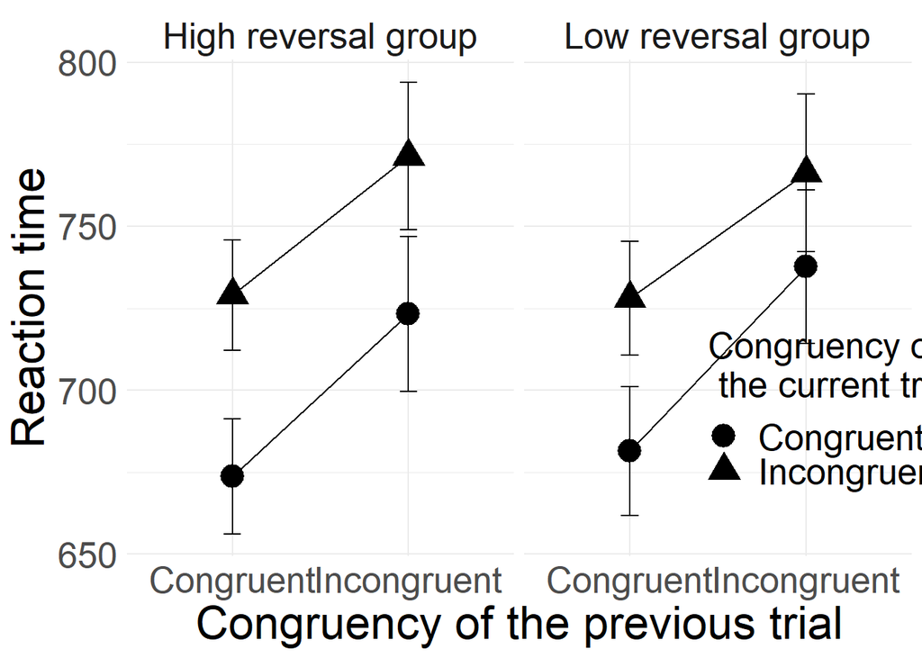

```r
main_analysis_rt_data %>%
  mutate(is_previous_congruent = case_when(is_previous_congruent ==  0L ~ "Incongruent",
                                           is_previous_congruent ==  1L ~ "Congruent"),
         is_congruent = case_when(is_congruent ==  0L ~ "Incongruent",
                                  is_congruent ==  1L ~ "Congruent"),
         reversal_group = case_when(reversal_group == "low" ~ "Low reversal group",
                                    reversal_group == "high" ~ "High reversal group")) %>%
  group_by(participant_id, reversal_group, is_previous_congruent, is_congruent) %>%
  summarise(par_mean_rt = mean(response_time, na.rm = T)) %>%
  group_by(is_previous_congruent, is_congruent, reversal_group) %>%
  summarise(N = n(),
            mean_rt = mean(par_mean_rt, na.rm = T),
            sd_rt = sd(par_mean_rt, na.rm = T),
            se_rt = sd_rt / sqrt(N)) %>%
  ggplot() +
  aes(x = is_previous_congruent,
      y = mean_rt,
      shape = is_congruent,
      group = is_congruent) +
  geom_path() +
  geom_point(size = 6) +
  geom_errorbar(aes(ymin = mean_rt - (se_rt * 1.96),
                    ymax = mean_rt + (se_rt * 1.96)),
                width = .1) +
  guides(color = FALSE) +
  xlab("Congruency of the previous trial")+
  ylab("Reaction time") +
  guides(shape = guide_legend(title = "Congruency of \n the current trial")) +
  facet_wrap( ~ reversal_group) +
  theme_minimal() +
  theme(axis.title = element_text(size = 25),
        axis.text = element_text(size = 20),
        legend.text = element_text(size = 20),
        legend.title = element_text(size = 20),
        strip.text.x = element_text(size = 20),
        legend.position = c(.9, .3))
```

Saving the figure.

```r
ggsave("Figures/Kan_Exp2_Rt_Cse_Rev_Plot.png", width = 14.4, height = 8, plot = last_plot())
```

The congruency sequence effect for the reaction time responses without reversal groups.

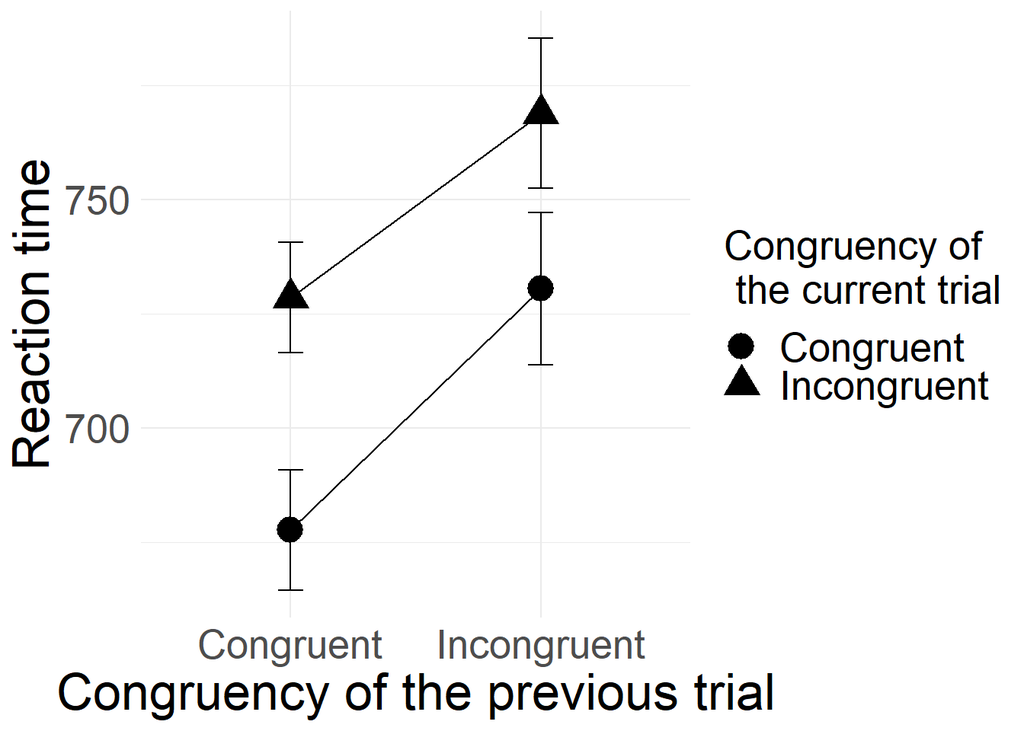

```r
main_analysis_rt_data %>%
  mutate(is_previous_congruent = case_when(is_previous_congruent ==  0L ~ "Incongruent",
                                           is_previous_congruent ==  1L ~ "Congruent"),
         is_congruent = case_when(is_congruent ==  0L ~ "Incongruent",
                                  is_congruent ==  1L ~ "Congruent")) %>%
  group_by(participant_id, is_previous_congruent, is_congruent) %>%
  summarise(par_mean_rt = mean(response_time, na.rm = T)) %>%
  group_by(is_previous_congruent, is_congruent) %>%
  summarise(N = n(),
            mean_rt = mean(par_mean_rt, na.rm = T),
            sd_rt = sd(par_mean_rt, na.rm = T),
            se_rt = sd_rt / sqrt(N)) %>%
  ggplot() +
  aes(x = is_previous_congruent,
      y = mean_rt,
      shape = is_congruent,
      group = is_congruent) +
  geom_path() +
  geom_point(size = 6) +
  geom_errorbar(aes(ymin = mean_rt - (se_rt * 1.96),
                    ymax = mean_rt + (se_rt * 1.96)),
                width = .1) +
  guides(color = FALSE) +
  xlab("Congruency of the previous trial")+
  ylab("Reaction time") +
  guides(shape = guide_legend(title = "Congruency of \n the current trial")) +
  theme_minimal() +
  theme(axis.title = element_text(size = 25),
        axis.text = element_text(size = 20),
        legend.text = element_text(size = 20),
        legend.title = element_text(size = 20),
        strip.text.x = element_text(size = 20))
```

Saving the figure.

```r
ggsave("Figures/Kan_Exp2_Rt_Cse_Plot.png", width = 14.4, height = 8, plot = last_plot())
```

### Two way interaction

#### Data preprocessing

We are calculating the mean reaction time per participant per condition (ci, ic, cc, ii).

```r
main_analysis_rt_aggregate <-
  main_analysis_rt_data %>%
  group_by(participant_id, is_congruent, is_previous_congruent) %>%
  summarise(rt_conditional_mean = mean(response_time, na.rm = T)) %>%
  ungroup()
```

Before the ANOVA we transform the predictor variables to factors.

```r
main_analysis_rt_aggregate <-
  main_analysis_rt_aggregate %>%
    mutate(is_congruent = as.factor(is_congruent),
           is_previous_congruent = as.factor(is_previous_congruent),
           participant_id = as.factor(participant_id))
```

The number of participants for the rt analysis.

```r
main_analysis_rt_aggregate %>%
  distinct(participant_id) %>%
  count()
```

```
## # A tibble: 1 x 1
##       n
##   <int>
## 1   163
```

We are running the ANOVA.

```r
anova_rt <-
  ezANOVA(data = main_analysis_rt_aggregate, dv = rt_conditional_mean, wid = participant_id, within = .(is_congruent, is_previous_congruent), type = 3)
```

Transforming the results of the ANOVA to a datatable.

```r
anova_rt <-
  as_tibble(anova_rt$ANOVA)
```

Extracting the F value and df from the ANOVA.

```r
anova_rt_f_value <-
  anova_rt %>%
  filter(Effect %in% c("is_congruent",
                       "is_previous_congruent",
                       "is_congruent:is_previous_congruent")) %>%
  transmute(term = case_when(Effect == "is_congruent" ~ "main_effect_congruent",
                             Effect == "is_previous_congruent" ~ "main_effect_previous_congruent",
                             Effect == "is_congruent:is_previous_congruent" ~ "interaction_effect"),
            f_value = F,
            df = DFd)
```

Calculating the raw effects per participant.

```r
main_analysis_rt_participant_level_raw_effect <-
  main_analysis_rt_aggregate %>%
  ungroup() %>%
  mutate(condition = case_when(is_previous_congruent == 0L & is_congruent == 0L ~ "ii",
                               is_previous_congruent == 0L & is_congruent == 1L ~ "ic",
                               is_previous_congruent == 1L & is_congruent == 0L ~ "ci",
                               is_previous_congruent == 1L & is_congruent == 1L ~ "cc",
                               TRUE ~ NA_character_)) %>%
  select(-is_previous_congruent, -is_congruent) %>%
  spread(key = condition, value = rt_conditional_mean) %>%
  mutate(congruency_effect = ((ci + ii) / 2) - ((cc + ic) / 2),
         previous_congruency_effect = ((ii + ic) / 2) - ((ci + cc) / 2),
         interaction_effect = (ci - cc) - (ii - ic),
         prev_cong = ci - cc,
         prev_incon = ii - ic,
         current_incongruent = ci - ii)
```

We are calculating the mean raw effect sizes.

```r
main_analysis_rt_raw_effect <-
  main_analysis_rt_participant_level_raw_effect %>%
  summarise(main_effect_congruent = mean(congruency_effect, na.rm = T),
            main_effect_previous_congruent = mean(previous_congruency_effect, na.rm = T),
            interaction_effect = mean(interaction_effect, na.rm = T),
            prev_cong_mean = mean(prev_cong, na.rm = T),
            prev_incon_mean = mean(prev_incon, na.rm = T)) %>%
  gather(key = "term", value = "raw_effect")
```

We are joining the F values and dfs with the raw effect sizes.

```r
main_analysis_rt_raw_effect <-
  main_analysis_rt_raw_effect %>%
  inner_join(., anova_rt_f_value, by = "term")
```

We are calculating the SE from the raw effect size and F value.

```r
main_analysis_rt_raw_effect <-
  main_analysis_rt_raw_effect %>%
  mutate(se = abs(raw_effect / sqrt(f_value)))
```

Assigning variables to calculate Bayes factor.

```r
# sd
rt_sd <-
  main_analysis_rt_raw_effect %>%
  filter(term == "interaction_effect") %>%
  pull(se)

# obtained
rt_obtained <-
  main_analysis_rt_raw_effect %>%
  filter(term == "interaction_effect") %>%
  pull(raw_effect)

# df
rt_df <-
  main_analysis_rt_raw_effect %>%
  filter(term == "interaction_effect") %>%
  pull(df)
```

Running the Bf analysis.

```r
Bf(sd = rt_sd,
   obtained = rt_obtained,
   dfdata = rt_df,
   meanoftheory = 0,
   sdtheory = 30,
   dftheory = 10^10,
   tail = 1)
```

```
## [1] 1.811392
```

### Three way interaction

#### Data preprocessing

We are calculating the mean reaction time per participant per condition (ci, ic, cc, ii).

```r
main_analysis_rt_aggregate <-
  main_analysis_rt_data %>%
  group_by(participant_id, is_congruent, is_previous_congruent, reversal_group) %>%
  summarise(rt_conditional_mean = mean(response_time, na.rm = T)) %>%
  ungroup()
```

Before the ANOVA we transform the predictor variables to factors.

```r
main_analysis_rt_aggregate <-
  main_analysis_rt_aggregate %>%
    mutate(is_congruent = as.factor(is_congruent),
           is_previous_congruent = as.factor(is_previous_congruent),
           participant_id = as.factor(participant_id),
           reversal_group = as.factor(reversal_group))
```

```r
main_analysis_rt_aggregate %>%
  group_by(reversal_group) %>%
  count()
```

```
## # A tibble: 2 x 2
## # Groups:   reversal_group [2]
##   reversal_group     n
##   <fct>          <int>
## 1 high             324
## 2 low              328
```

The number of participants for the rt analysis.

```r
main_analysis_rt_aggregate %>%
  distinct(participant_id) %>%
  count()
```

```
## # A tibble: 1 x 1
##       n
##   <int>
## 1   163
```

We are running the ANOVA.

```r
anova_rt <-
  ezANOVA(data = main_analysis_rt_aggregate, dv = rt_conditional_mean, wid = participant_id, within = .(is_congruent, is_previous_congruent), between = reversal_group, type = 3)
```

Transforming the results of the ANOVA to a datatable.

```r
anova_rt <-
  as_tibble(anova_rt$ANOVA)
```

Extracting the F value and df from the ANOVA.

```r
anova_rt_f_value <-
  anova_rt %>%
  filter(Effect %in% c("is_congruent",
                       "is_previous_congruent",
                       "reversal_group:is_congruent:is_previous_congruent")) %>%
  transmute(term = case_when(Effect == "is_congruent" ~ "main_effect_congruent",
                             Effect == "is_previous_congruent" ~ "main_effect_previous_congruent",
                             Effect == "reversal_group:is_congruent:is_previous_congruent" ~ "interaction_effect"),
            f_value = F,
            df = DFd)
```

Calculating the raw effects per participant.

```r
main_analysis_rt_participant_level_raw_effect <-
  main_analysis_rt_aggregate %>%
  ungroup() %>%
  mutate(condition = case_when(is_previous_congruent == 0L & is_congruent == 0L ~ "ii",
                               is_previous_congruent == 0L & is_congruent == 1L ~ "ic",
                               is_previous_congruent == 1L & is_congruent == 0L ~ "ci",
                               is_previous_congruent == 1L & is_congruent == 1L ~ "cc",
                               TRUE ~ NA_character_)) %>%
  select(-is_previous_congruent, -is_congruent) %>%
  spread(key = condition, value = rt_conditional_mean) %>%
  mutate(congruency_effect = ((ci + ii) / 2) - ((cc + ic) / 2),
         previous_congruency_effect = ((ii + ic) / 2) - ((ci + cc) / 2),
         interaction_effect = (ci - cc) - (ii - ic),
         prev_cong = ci - cc,
         prev_incon = ii - ic,
         current_incongruent = ci - ii)
```

We are calculating the mean raw effect sizes.

```r
main_analysis_rt_raw_effect <-
  main_analysis_rt_participant_level_raw_effect %>%
  group_by(reversal_group) %>%
  summarise(main_effect_congruent = mean(congruency_effect, na.rm = T),
            main_effect_previous_congruent = mean(previous_congruency_effect, na.rm = T),
            interaction_effect = mean(interaction_effect, na.rm = T),
            prev_cong_mean = mean(prev_cong, na.rm = T),
            prev_incon_mean = mean(prev_incon, na.rm = T)) %>%
  gather(key = "term", value = "raw_effect", -reversal_group) %>%
  spread(key = "reversal_group", value = "raw_effect")
```

We are extracting the low raw effect sizes from the high raw effect sizes according to the hypothesis.

```r
main_analysis_rt_raw_effect <-
  main_analysis_rt_raw_effect %>%
  ungroup() %>%
  mutate(raw_effect = high - low) %>%
  select(-high,
         -low)
```

We are joining the F values and dfs with the raw effect sizes.

```r
main_analysis_rt_raw_effect <-
  main_analysis_rt_raw_effect %>%
  inner_join(., anova_rt_f_value, by = "term")
```

We are calculating the se from the raw effect size and f value.

```r
main_analysis_rt_raw_effect <-
  main_analysis_rt_raw_effect %>%
  mutate(se = abs(raw_effect / sqrt(f_value)))
```

Assignig variables to calculate bayes factor.

```r
# sd
rt_sd <-
  main_analysis_rt_raw_effect %>%
  filter(term == "interaction_effect") %>%
  pull(se)

# obtained
rt_obtained <-
  main_analysis_rt_raw_effect %>%
  filter(term == "interaction_effect") %>%
  pull(raw_effect)

# df
rt_df <-
  main_analysis_rt_raw_effect %>%
  filter(term == "interaction_effect") %>%
  pull(df)
```

Running the Bf analysis.

```r
Bf(sd = rt_sd,
   obtained = rt_obtained,
   dfdata = rt_df,
   meanoftheory = 0,
   sdtheory = 30,
   dftheory = 10^10,
   tail = 1)
```

```
## [1] 0.2798037
```

### Correlation

We are calculating the correlation between the mean number of reversals per participant and the size of the conflict adaptation operationalized by the current incongruent difference.

First we create a dataset for the comparison.

```r
main_analysis_rt_cor_data <-
  main_analysis_rt_data %>%
  group_by(participant_id, is_congruent, is_previous_congruent, reversal_group, mean_reversal) %>%
  summarise(rt_conditional_mean = mean(response_time, na.rm = T)) %>%
  ungroup() %>%
  mutate(condition = case_when(is_previous_congruent == 0L & is_congruent == 0L ~ "ii",
                               is_previous_congruent == 0L & is_congruent == 1L ~ "ic",
                               is_previous_congruent == 1L & is_congruent == 0L ~ "ci",
                               is_previous_congruent == 1L & is_congruent == 1L ~ "cc",
                               TRUE ~ NA_character_)) %>%
  select(-is_previous_congruent, -is_congruent) %>%
  spread(key = condition, value = rt_conditional_mean) %>%
  mutate(current_incongruent = ci - ii) %>%
  select(participant_id,
         current_incongruent,
         mean_reversal,
         reversal_group)
```

We are visualizing the comparison on a figure.

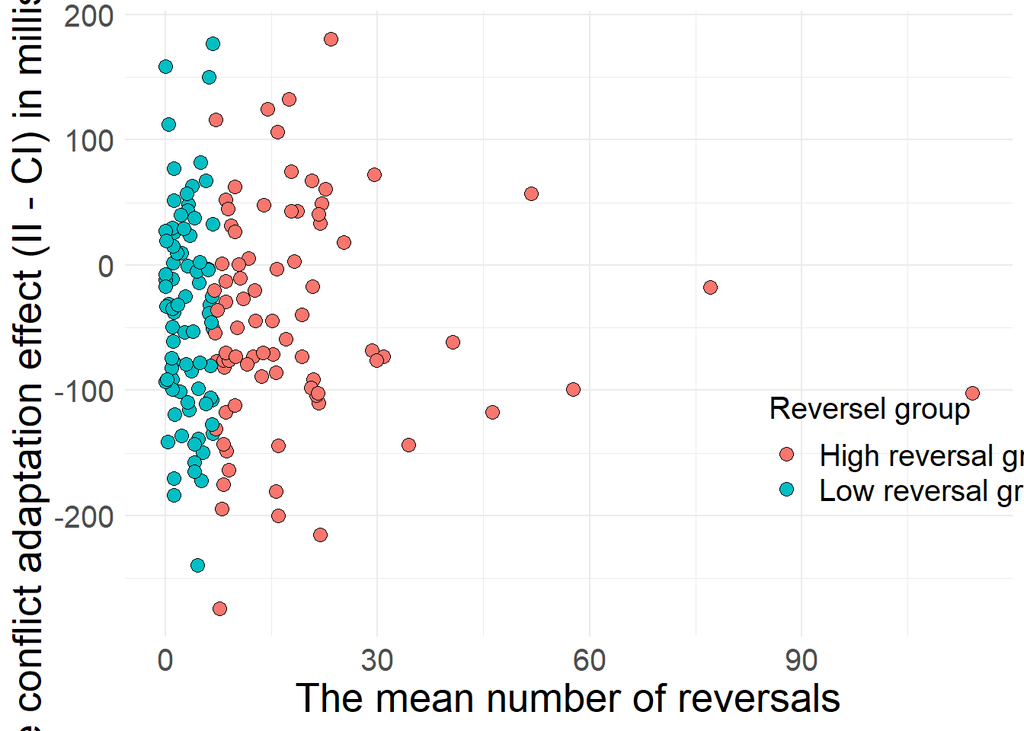

```r
main_analysis_rt_cor_data %>%
  mutate(reversal_group = case_when(reversal_group == "low" ~ "Low reversal group",
                                    reversal_group == "high" ~ "High reversal group")) %>%
  ggplot() +
  aes(x = mean_reversal,
      y = current_incongruent,
      fill = reversal_group) +
  geom_jitter(colour = "black", pch = 21, size = 3) +
  guides(shape = guide_legend(title = "Reversal group")) +
  labs(x = "The mean number of reversals",
       y = "The conflict adaptation effect (II - CI) in milliseconds",
       fill = "Reversel group") +
  theme_minimal() +
  theme(axis.title = element_text(size = 20),
        axis.text = element_text(size = 15),
        legend.text = element_text(size = 15),
        legend.title = element_text(size = 15),
        legend.position = c(.9, .3))
```

Save the plot.

```r
ggsave("Figures/Kan_Exp2_Correlation_Plot.png", width = 14.4, height = 8, plot = last_plot())
```

Running the correlation.

```r
cor.test(main_analysis_rt_cor_data$current_incongruent,
         main_analysis_rt_cor_data$mean_reversal,
         method = "pearson")
```

```
##
##  Pearson's product-moment correlation
##
## data:  main_analysis_rt_cor_data$current_incongruent and main_analysis_rt_cor_data$mean_reversal
## t = -0.25675, df = 161, p-value = 0.7977
## alternative hypothesis: true correlation is not equal to 0
## 95 percent confidence interval:
##  -0.1734118  0.1339064
## sample estimates:
##         cor
## -0.02023055
```

## Accuracy analysis

### Importing data

```r
main_analysis_acc <- read_tsv("Data/Processed/Exp2/Kan_Processed_Exp2_Main_Acc_data.tsv")
```

### Exploratory data analysis

The number of trials per participant.

```r
main_analysis_acc %>%
  group_by(participant_id) %>%
  count()
```

```
## # A tibble: 168 x 2
## # Groups:   participant_id [168]
##    participant_id     n
##    <chr>          <int>
##  1 0001              42
##  2 0002              42
##  3 0003              46
##  4 0004              49
##  5 0005              44
##  6 0006              44
##  7 0007              46
##  8 0008              42
##  9 0009              46
## 10 0010              74
## # ... with 158 more rows
```

The number of participants.

```r
main_analysis_acc %>%
  distinct(participant_id) %>%
  count()
```

```
## # A tibble: 1 x 1
##       n
##   <int>
## 1   168
```

The number and frequency of correct trials. There are different number of trials per participant because each participant was assigned to a different set of trails (out of 6) randomly. These sets contained different number of test trials that satisfy the criteria to be the part of the analysis.

```r
main_analysis_acc %>%
  group_by(participant_id, is_correct) %>%
  count() %>%
  group_by(participant_id) %>%
  mutate(sum_n = sum(n),
         freq = n / sum_n * 100) %>%
  filter(is_correct == 1L)
```

```
## # A tibble: 163 x 5
## # Groups:   participant_id [163]
##    participant_id is_correct     n sum_n  freq
##    <chr>               <dbl> <int> <int> <dbl>
##  1 0001                    1    33    42  78.6
##  2 0002                    1    41    42  97.6
##  3 0003                    1    33    46  71.7
##  4 0004                    1    24    49  49.0
##  5 0005                    1    23    44  52.3
##  6 0006                    1    36    44  81.8
##  7 0007                    1    45    46  97.8
##  8 0008                    1    33    42  78.6
##  9 0009                    1    39    46  84.8
## 10 0010                    1    56    74  75.7
## # ... with 153 more rows
```

### Figures

Figure with reversal groups.

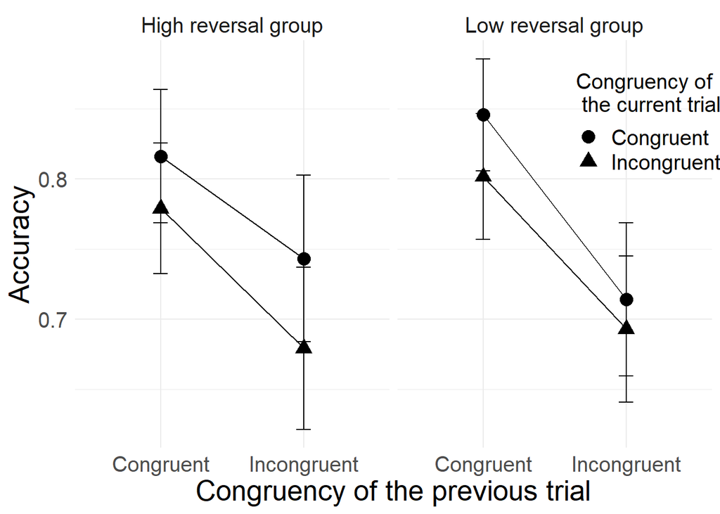

```r
main_analysis_acc %>%
  mutate(is_previous_congruent = case_when(is_previous_congruent ==  0L ~ "Incongruent",
                                           is_previous_congruent ==  1L ~ "Congruent"),
         is_congruent = case_when(is_congruent ==  0L ~ "Incongruent",
                                  is_congruent ==  1L ~ "Congruent"),
         reversal_group = case_when(reversal_group == "low" ~ "Low reversal group",
                                    reversal_group == "high" ~ "High reversal group")) %>%
  group_by(is_previous_congruent, is_congruent, reversal_group, participant_id) %>%
  summarise(par_mean_acc = mean(is_correct, na.rm = T)) %>%
  group_by(is_previous_congruent, is_congruent, reversal_group) %>%
  summarise(N = n(),
            mean_acc = mean(par_mean_acc, na.rm = T),
            sd_acc = sd(par_mean_acc, na.rm = T),
            se_acc = sd_acc / sqrt(N)) %>%
  ggplot() +
  aes(x = is_previous_congruent,
      y =  mean_acc,
      shape = is_congruent,
      group = is_congruent) +
  geom_path() +
  geom_point(size = 4) +
  geom_errorbar(aes(ymin = mean_acc - (se_acc * 1.96),
                    ymax = mean_acc + (se_acc * 1.96)),
                width = .1) +
  guides(color = FALSE) +
  xlab("Congruency of the previous trial")+
  ylab("Accuracy") +
  guides(shape = guide_legend(title = "Congruency of \n the current trial")) +
  facet_wrap( ~ reversal_group) +
  theme_minimal() +
  theme(axis.title = element_text(size = 20),
        axis.text = element_text(size = 15),
        legend.text = element_text(size = 15),
        legend.title = element_text(size = 15),
        strip.text.x = element_text(size = 15),
        legend.position = c(.9, .8))
```

Saving the figure.

```r
ggsave("Figures/Kan_Exp2_Acc_Cse_Rev_Plot.png", width = 14.4, height = 8, plot = last_plot())
```

Figure without reversal groups.

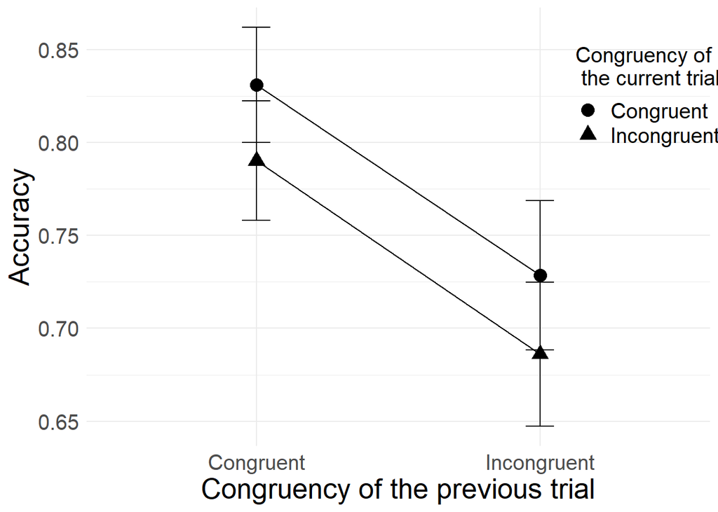

```r
main_analysis_acc %>%
  mutate(is_previous_congruent = case_when(is_previous_congruent ==  0L ~ "Incongruent",
                                           is_previous_congruent ==  1L ~ "Congruent"),
         is_congruent = case_when(is_congruent ==  0L ~ "Incongruent",
                                  is_congruent ==  1L ~ "Congruent")) %>%
  group_by(participant_id, is_previous_congruent, is_congruent) %>%
  summarise(par_mean_acc = mean(is_correct, na.rm = T)) %>%
  group_by(is_previous_congruent, is_congruent) %>%
  summarise(N = n(),
            mean_acc = mean(par_mean_acc, na.rm = T),
            sd_acc = sd(par_mean_acc, na.rm = T),
            se_acc = sd_acc / sqrt(N)) %>%
  ggplot() +
  aes(x = is_previous_congruent,
      y =  mean_acc,
      shape = is_congruent,
      group = is_congruent) +
  geom_path() +
  geom_point(size = 4) +
  geom_errorbar(aes(ymin = mean_acc - (se_acc * 1.96),
                    ymax = mean_acc + (se_acc * 1.96)),
                width = .1) +
  guides(color = FALSE) +
  xlab("Congruency of the previous trial")+
  ylab("Accuracy") +
  guides(shape = guide_legend(title = "Congruency of \n the current trial")) +
  theme_minimal() +
  theme(axis.title = element_text(size = 20),
        axis.text = element_text(size = 15),
        legend.text = element_text(size = 15),
        legend.title = element_text(size = 15),
        strip.text.x = element_text(size = 15),
        legend.position = c(.9, .8))
```

Saving the figure.

```r
ggsave("Figures/Kan_Exp2_Acc_Cse_Plot.png", width = 14.4, height = 8, plot = last_plot())
```

### Two way interaction

#### Data preprocessing

we are calculating the conditional mean of the correct trials per particpant and per condition (CC, II, CI, IC).

```r
main_analysis_acc_aggregate <-
  main_analysis_acc %>%
  group_by(participant_id, is_congruent, is_previous_congruent) %>%
  summarise(acc_conditional_mean = mean(is_correct, na.rm = T)) %>%
  ungroup()
```

Transfer independent variables used in the ANOVA to factors.

```r
main_analysis_acc_aggregate <-
  main_analysis_acc_aggregate %>%
  mutate(is_congruent = as_factor(is_congruent),
         is_previous_congruent = as_factor(is_previous_congruent),
         participant_id = as_factor(participant_id))
```

Running the mixed ANOVA.

```r
anova_acc <-
  ezANOVA(data = main_analysis_acc_aggregate, dv = acc_conditional_mean, wid = participant_id, within = .(is_congruent, is_previous_congruent), type = 3)
```

Transforming the output of the ANOVA to a tibble.

```r
anova_acc <-
  as_tibble(anova_acc$ANOVA)
```

Extract the F value and df2 from the ANOVA.

```r
anova_acc_f_value <-
  anova_acc %>%
  filter(Effect %in% c("is_congruent",
                       "is_previous_congruent",
                       "is_congruent:is_previous_congruent")) %>%
  transmute(term = case_when(Effect == "is_congruent" ~ "main_effect_congruent",
                             Effect == "is_previous_congruent" ~ "main_effect_previous_congruent",
                             Effect == "is_congruent:is_previous_congruent" ~ "interaction_effect"),
            f_value = F,
            df = DFd)
```

We calculate the raw effects per participant.

```r
main_analysis_acc_participant_level_raw_effect <-
  main_analysis_acc_aggregate %>%
  ungroup() %>%
  mutate(condition = case_when(is_previous_congruent == 0L & is_congruent == 0L ~ "ii",
                               is_previous_congruent == 0L & is_congruent == 1L ~ "ic",
                               is_previous_congruent == 1L & is_congruent == 0L ~ "ci",
                               is_previous_congruent == 1L & is_congruent == 1L ~ "cc",
                               TRUE ~ NA_character_)) %>%
  select(-is_previous_congruent, -is_congruent) %>%
  spread(key = condition, value = acc_conditional_mean) %>%
  mutate(congruency_effect = ((cc + ic) / 2) - ((ci + ii) / 2),
         previous_congruency_effect = ((ci + cc) / 2) - ((ii + ic) / 2),
         interaction_effect = (cc - ci) - (ic - ii),
         current_incongruent = ii - ci)
```

We summarize the participant level data for further analysis.

```r
main_analysis_acc_raw_effect <-
  main_analysis_acc_participant_level_raw_effect %>%
  summarise(main_effect_congruent = mean(congruency_effect, na.rm = T),
            main_effect_previous_congruent = mean(previous_congruency_effect, na.rm = T),
            interaction_effect = mean(interaction_effect, na.rm = T)) %>%
  gather(key = "term", value = "raw_effect")
```

We join the calculated raw effects with the F value and the df from the ANOVA.

```r
main_analysis_acc_raw_effect <-
  main_analysis_acc_raw_effect %>%
  inner_join(., anova_acc_f_value, by = "term")
```

We valvulate the SE corresponding to the raw effects.

```r
main_analysis_acc_raw_effect <-
  main_analysis_acc_raw_effect %>%
  mutate(se = abs(raw_effect / sqrt(f_value)))
```

Saving values needed for the Bayes factor analysis.

```r
# SE
acc_sd <-
  main_analysis_acc_raw_effect %>%
  filter(term == "interaction_effect") %>%
  pull(se)

# Raw effect
acc_obtained <-
  main_analysis_acc_raw_effect %>%
  filter(term == "interaction_effect") %>%
  pull(raw_effect)

# Degrees of freedom
acc_df <-
  main_analysis_acc_raw_effect %>%
  filter(term == "interaction_effect") %>%
  pull(df)
```

Calculating the Bayes factor.

```r
Bf(sd = acc_sd,
   obtained = acc_obtained,
   dfdata = acc_df,
   meanoftheory = 0,
   sdtheory = .03,
   dftheory = 10^10,
   tail = 1)
```

```
## [1] 0.4920765
```

### Three way interaction

#### Data preprocessing

we are calculating the conditional mean of the correct trials per particpant and per condition (CC, II, CI, IC).

```r
main_analysis_acc_aggregate <-
  main_analysis_acc %>%
  group_by(participant_id, reversal_group, is_congruent, is_previous_congruent) %>%
  summarise(acc_conditional_mean = mean(is_correct, na.rm = T)) %>%
  ungroup()
```

The number of participants in each reversal group.

```r
main_analysis_acc_aggregate %>%
  distinct(participant_id, .keep_all = T) %>%
  group_by(reversal_group) %>%
  count()
```

```
## # A tibble: 2 x 2
## # Groups:   reversal_group [2]
##   reversal_group     n
##   <chr>          <int>
## 1 high              84
## 2 low               84
```

Transfer independent variables used in the ANOVA to factors.

```r
main_analysis_acc_aggregate <-
  main_analysis_acc_aggregate %>%
  mutate(is_congruent = as_factor(is_congruent),
         is_previous_congruent = as_factor(is_previous_congruent),
         participant_id = as_factor(participant_id),
         reversal_group = as_factor(reversal_group))
```

Running the mixed ANOVA.

```r
anova_acc <-
  ezANOVA(data = main_analysis_acc_aggregate, dv = acc_conditional_mean, wid = participant_id, within = .(is_congruent, is_previous_congruent), between = reversal_group, type = 3)
```

Transfroming the output of the ANOVA to a tibble.

```r
anova_acc <-
  as_tibble(anova_acc$ANOVA)
```

Extract the F valu and df2 from the ANOVA.

```r
anova_acc_f_value <-
  anova_acc %>%
  filter(Effect %in% c("is_congruent",
                       "is_previous_congruent",
                       "reversal_group:is_congruent:is_previous_congruent")) %>%
  transmute(term = case_when(Effect == "is_congruent" ~ "main_effect_congruent",
                             Effect == "is_previous_congruent" ~ "main_effect_previous_congruent",
                             Effect == "reversal_group:is_congruent:is_previous_congruent" ~ "interaction_effect"),
            f_value = F,
            df = DFd)
```

We calculate the raw effects per participant.

```r
main_analysis_acc_participant_level_raw_effect <-
  main_analysis_acc_aggregate %>%
  ungroup() %>%
  mutate(condition = case_when(is_previous_congruent == 0L & is_congruent == 0L ~ "ii",
                               is_previous_congruent == 0L & is_congruent == 1L ~ "ic",
                               is_previous_congruent == 1L & is_congruent == 0L ~ "ci",
                               is_previous_congruent == 1L & is_congruent == 1L ~ "cc",
                               TRUE ~ NA_character_)) %>%
  select(-is_previous_congruent, -is_congruent) %>%
  spread(key = condition, value = acc_conditional_mean) %>%
  mutate(congruency_effect = ((cc + ic) / 2) - ((ci + ii) / 2),
         previous_congruency_effect = ((ci + cc) / 2) - ((ii + ic) / 2),
         interaction_effect = (cc - ci) - (ic - ii),
         current_incongruent = ii - ci)
```

We summarise the participant level data for further analysis.

```r
main_analysis_acc_raw_effect <-
  main_analysis_acc_participant_level_raw_effect %>%
  group_by(reversal_group) %>%
  summarise(main_effect_congruent = mean(congruency_effect, na.rm = T),
            main_effect_previous_congruent = mean(previous_congruency_effect, na.rm = T),
            interaction_effect = mean(interaction_effect, na.rm = T)) %>%
  gather(key = "term", value = "raw_effect", -reversal_group) %>%
  spread(key = "reversal_group", value = "raw_effect")
```

```r
main_analysis_acc_raw_effect <-
  main_analysis_acc_raw_effect %>%
  ungroup() %>%
  mutate(raw_effect = high - low) %>%
  select(-high,
         -low)
```

We join the calculated raw effects with the F value and the df from the ANOVA.

```r
main_analysis_acc_raw_effect <-
  main_analysis_acc_raw_effect %>%
  inner_join(., anova_acc_f_value, by = "term")
```

We valvulate the SE corresponding to the raw effects.

```r
main_analysis_acc_raw_effect <-
  main_analysis_acc_raw_effect %>%
  mutate(se = abs(raw_effect / sqrt(f_value)))
```

Saving values needed for the Bayes factor analysis.

```r
# SE
acc_sd <-
  main_analysis_acc_raw_effect %>%
  filter(term == "interaction_effect") %>%
  pull(se)

# Raw effect
acc_obtained <-
  main_analysis_acc_raw_effect %>%
  filter(term == "interaction_effect") %>%
  pull(raw_effect)

# Degrees of freedom
acc_df <-
  main_analysis_acc_raw_effect %>%
  filter(term == "interaction_effect") %>%
  pull(df)
```

Calculating the Bayes factor.

```r
Bf(sd = acc_sd,
   obtained = acc_obtained,
   dfdata = acc_df,
   meanoftheory = 0,
   sdtheory = .03,
   dftheory = 10^10,
   tail = 1)
```

```
## [1] 0.4441892
```

### Correlation

```r
main_analysis_acc_cor <-
  main_analysis_acc %>%
  group_by(participant_id, is_congruent, is_previous_congruent, reversal_group, mean_reversal) %>%
  summarise(acc_conditional_mean = mean(is_correct, na.rm = T)) %>%
  ungroup() %>%
  mutate(condition = case_when(is_previous_congruent == 0L & is_congruent == 0L ~ "ii",
                               is_previous_congruent == 0L & is_congruent == 1L ~ "ic",
                               is_previous_congruent == 1L & is_congruent == 0L ~ "ci",
                               is_previous_congruent == 1L & is_congruent == 1L ~ "cc",
                               TRUE ~ NA_character_)) %>%
  select(-is_previous_congruent, -is_congruent) %>%
  spread(key = condition, value = acc_conditional_mean) %>%
  mutate(current_incongruent = ci - ii) %>%
  select(participant_id,
         current_incongruent,
         mean_reversal,
         reversal_group)
```

Cisualizing the correlation on a figure.

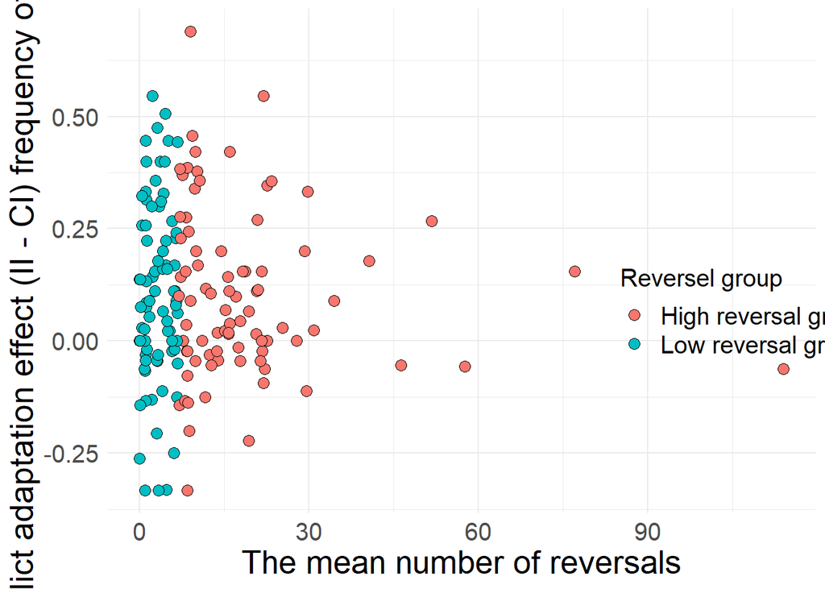

```r
main_analysis_acc_cor %>%
  mutate(reversal_group = case_when(reversal_group == "low" ~ "Low reversal group",
                                    reversal_group == "high" ~ "High reversal group")) %>%
  ggplot() +
  aes(x = mean_reversal,
      y = current_incongruent,
      fill = reversal_group) +
  geom_jitter(colour="black", pch=21, size = 3) +
  guides(shape = guide_legend(title = "Reversal group")) +
  labs(x = "The mean number of reversals",
       y = "The conflict adaptation effect (II - CI) frequency of correct trials",
       fill = "Reversel group") +
  theme_minimal() +
  theme(axis.title = element_text(size = 20),
        axis.text = element_text(size = 15),
        legend.text = element_text(size = 15),
        legend.title = element_text(size = 15),
        legend.position = c(.9, .4))
```

Running the correlction test.

```r
cor.test(main_analysis_acc_cor$current_incongruent,
         main_analysis_acc_cor$mean_reversal,
         method = "pearson")
```

```
##
##  Pearson's product-moment correlation
##
## data:  main_analysis_acc_cor$current_incongruent and main_analysis_acc_cor$mean_reversal
## t = -0.74574, df = 166, p-value = 0.4569
## alternative hypothesis: true correlation is not equal to 0
## 95 percent confidence interval:
##  -0.20737921  0.09445237
## sample estimates:
##         cor
## -0.05778379
```

# Exp3

## Reaction time analysis

### Import data

```r
main_analysis_rt_data <-
  read_tsv("Data/Processed/Exp3/Kan_Processed_Exp3_Main_Rt_data.tsv")
```

### Exploratory data analysis

The number of response per participant.

```r
main_analysis_rt_data %>%
  group_by(participant_id) %>%
  count()
```

```
## # A tibble: 80 x 2
## # Groups:   participant_id [80]
##    participant_id     n
##    <chr>          <int>
##  1 0001              67
##  2 0002              61
##  3 0003              39
##  4 0005              36
##  5 0006              65
##  6 0008              28
##  7 0010              36
##  8 0011              45
##  9 0013              35
## 10 0014              40
## # ... with 70 more rows
```

The number of participants.

```r
main_analysis_rt_data %>%
  distinct(participant_id) %>%
  count()
```

```
## # A tibble: 1 x 1
##       n
##   <int>
## 1    80
```

### Figures

The congruency sequence effect for the reaction time responses.

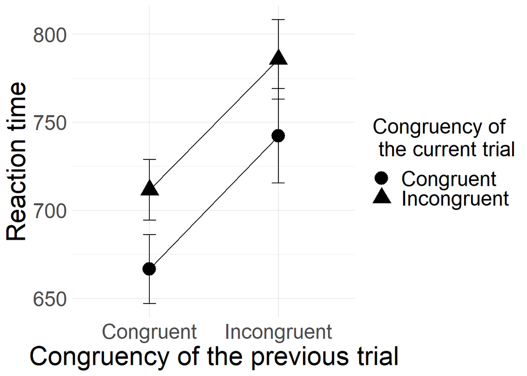

```r
main_analysis_rt_data %>%
  mutate(is_previous_congruent = case_when(is_previous_congruent ==  0L ~ "Incongruent",
                                           is_previous_congruent ==  1L ~ "Congruent"),
         is_congruent = case_when(is_congruent ==  0L ~ "Incongruent",
                                  is_congruent ==  1L ~ "Congruent")) %>%
  group_by(participant_id, is_previous_congruent, is_congruent) %>%
  summarise(par_mean_rt = mean(response_time, na.rm = T)) %>%
  group_by(is_previous_congruent, is_congruent) %>%
  summarise(N = n(),
            mean_rt = mean(par_mean_rt, na.rm = T),
            sd_rt = sd(par_mean_rt, na.rm = T),
            se_rt = sd_rt / sqrt(N)) %>%
  ggplot() +
  aes(x = is_previous_congruent,
      y = mean_rt,
      shape = is_congruent,
      group = is_congruent) +
  geom_path() +
  geom_point(size = 6) +
  geom_errorbar(aes(ymin = mean_rt - (se_rt * 1.96),
                    ymax = mean_rt + (se_rt * 1.96)),
                width = .1) +
  guides(color = FALSE) +
  xlab("Congruency of the previous trial")+
  ylab("Reaction time") +
  guides(shape = guide_legend(title = "Congruency of \n the current trial")) +
  theme_minimal() +
  theme(axis.title = element_text(size = 25),
        axis.text = element_text(size = 20),
        legend.text = element_text(size = 20),
        legend.title = element_text(size = 20),
        strip.text.x = element_text(size = 20))
```

Saving the figure.

```r
ggsave("Figures/Kan_Exp3_Rt_Cse_Plot.png", width = 14.4, height = 8, plot = last_plot())
```

### Crucial tests

#### Data preprocessing

We are calculating the mean reaction time per participant per condition (ci, ic, cc, ii).

```r
main_analysis_rt_aggregate <-
  main_analysis_rt_data %>%
  group_by(participant_id, is_congruent, is_previous_congruent) %>%
  summarise(rt_conditional_mean = mean(response_time, na.rm = T)) %>%
  ungroup()
```

Before the ANOVA we transform the predictor variables to factors.

```r
main_analysis_rt_aggregate <-
  main_analysis_rt_aggregate %>%
    mutate(is_congruent = as.factor(is_congruent),
           is_previous_congruent = as.factor(is_previous_congruent),
           participant_id = as.factor(participant_id))
```

We are running the ANOVA.

```r
anova_rt <-
  ezANOVA(data = main_analysis_rt_aggregate, dv = rt_conditional_mean, wid = participant_id, within = .(is_congruent, is_previous_congruent), type = 3)
```

Transforming the results of the ANOVa to a datatable.

```r
anova_rt <-
  as_tibble(anova_rt$ANOVA)
```

Extracting F value and df from the ANOVA.

```r
anova_rt_f_value <-
  anova_rt %>%
  filter(Effect %in% c("is_congruent",
                       "is_previous_congruent",
                       "is_congruent:is_previous_congruent")) %>%
  transmute(term = case_when(Effect == "is_congruent" ~ "main_effect_congruent",
                             Effect == "is_previous_congruent" ~ "main_effect_previous_congruent",
                             Effect == "is_congruent:is_previous_congruent" ~ "interaction_effect"),
            f_value = F,
            df = DFd)
```

Calculating the raw effects per participant.

```r
main_analysis_rt_participant_level_raw_effect <-
  main_analysis_rt_aggregate %>%
  ungroup() %>%
  mutate(condition = case_when(is_previous_congruent == 0L & is_congruent == 0L ~ "ii",
                               is_previous_congruent == 0L & is_congruent == 1L ~ "ic",
                               is_previous_congruent == 1L & is_congruent == 0L ~ "ci",
                               is_previous_congruent == 1L & is_congruent == 1L ~ "cc",
                               TRUE ~ NA_character_)) %>%
  select(-is_previous_congruent, -is_congruent) %>%
  spread(key = condition, value = rt_conditional_mean) %>%
  mutate(congruency_effect = ((ci + ii) / 2) - ((cc + ic) / 2),
         previous_congruency_effect = ((ii + ic) / 2) - ((ci + cc) / 2),
         interaction_effect = (ci - cc) - (ii - ic),
         prev_cong = ci - cc,
         prev_incon = ii - ic,
         current_incongruent = ci - ii)
```

Summarizing the mean raw effects.

```r
main_analysis_rt_raw_effect <-
  main_analysis_rt_participant_level_raw_effect %>%
  summarise(main_effect_congruent = mean(congruency_effect, na.rm = T),
            main_effect_previous_congruent = mean(previous_congruency_effect, na.rm = T),
            interaction_effect = mean(interaction_effect, na.rm = T)) %>%
  gather(key = "term", value = "raw_effect")
```

Joining the raw effects with the F value and df.

```r
main_analysis_rt_raw_effect <-
  main_analysis_rt_raw_effect %>%
  inner_join(., anova_rt_f_value, by = "term")
```

Calculating se.

```r
main_analysis_rt_raw_effect <-
  main_analysis_rt_raw_effect %>%
  mutate(se = abs(raw_effect / sqrt(f_value)))
```

#### Running the analysis

Saving the values needed for the analysis.

```r
# Obtained sd
rt_se <-
  main_analysis_rt_raw_effect %>%
  filter(term == "interaction_effect") %>%
  pull(se)

# Obtained effect
rt_effect <-
  main_analysis_rt_raw_effect %>%
  filter(term == "interaction_effect") %>%
  pull(raw_effect)

# Df
rt_df <-
  main_analysis_rt_raw_effect %>%
  filter(term == "interaction_effect") %>%
  pull(df)
```

Running the Bayes factor analysis.

```r
Bf(sd = rt_se,
   obtained = rt_effect,
   dfdata = rt_df,
   meanoftheory = 0,
   sdtheory = 30,
   dftheory = 10^10,
   tail = 1)
```

```
## [1] 0.358782
```

## Accuracy analysis

### Importing data

```r
main_analysis_acc <- read_tsv("Data/Processed/Exp3/Kan_Processed_Exp3_Main_Acc_data.tsv")
```

### Exploratory data analysis

The number and frequency of correct trials.

```r
main_analysis_acc %>%
  group_by(participant_id, is_correct) %>%
  count() %>%
  group_by(participant_id) %>%
  mutate(sum_n = sum(n),
         freq = n / sum_n * 100) %>%
  filter(is_correct == 1L)
```

```
## # A tibble: 80 x 5
## # Groups:   participant_id [80]
##    participant_id is_correct     n sum_n  freq
##    <chr>               <dbl> <int> <int> <dbl>
##  1 0001                    1    67    74  90.5
##  2 0002                    1    61    74  82.4
##  3 0003                    1    39    46  84.8
##  4 0005                    1    36    42  85.7
##  5 0006                    1    65    74  87.8
##  6 0008                    1    28    42  66.7
##  7 0010                    1    36    44  81.8
##  8 0011                    1    45    49  91.8
##  9 0013                    1    35    49  71.4
## 10 0014                    1    40    42  95.2
## # ... with 70 more rows
```

The number of participants.

```r
main_analysis_acc %>%
  distinct(participant_id) %>%
  count()
```

```
## # A tibble: 1 x 1
##       n
##   <int>
## 1    80
```

### Figures

Congruency sequence effect of accuracy.

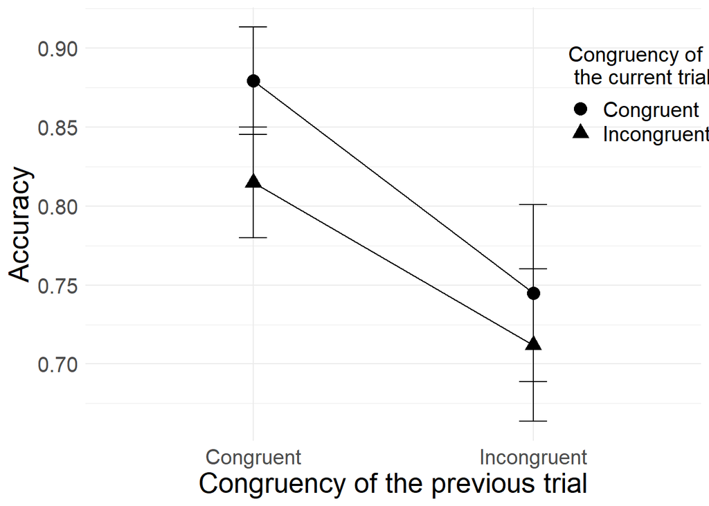

```r
main_analysis_acc %>%
  mutate(is_previous_congruent = case_when(is_previous_congruent ==  0L ~ "Incongruent",
                                           is_previous_congruent ==  1L ~ "Congruent"),
         is_congruent = case_when(is_congruent ==  0L ~ "Incongruent",
                                  is_congruent ==  1L ~ "Congruent")) %>%
  group_by(participant_id, is_previous_congruent, is_congruent) %>%
  summarise(par_mean_acc = mean(is_correct, na.rm = T)) %>%
  group_by(is_previous_congruent, is_congruent) %>%
  summarise(N = n(),
            mean_acc = mean(par_mean_acc, na.rm = T),
            sd_acc = sd(par_mean_acc, na.rm = T),
            se_acc = sd_acc / sqrt(N)) %>%
  ggplot() +
  aes(x = is_previous_congruent,
      y =  mean_acc,
      shape = is_congruent,
      group = is_congruent) +
  geom_path() +
  geom_point(size = 4) +
  geom_errorbar(aes(ymin = mean_acc - (se_acc * 1.96),
                    ymax = mean_acc + (se_acc * 1.96)),
                width = .1) +
  guides(color = FALSE) +
  xlab("Congruency of the previous trial")+
  ylab("Accuracy") +
  guides(shape = guide_legend(title = "Congruency of \n the current trial")) +
  theme_minimal() +
  theme(axis.title = element_text(size = 20),
        axis.text = element_text(size = 15),
        legend.text = element_text(size = 15),
        legend.title = element_text(size = 15),
        strip.text.x = element_text(size = 15),
        legend.position = c(.9, .8))
```

Saving the figure.

```r
ggsave("Figures/Kan_Exp3_Acc_Congruency_Plot.png", width = 14.4, height = 8, plot = last_plot())
```

### Data preprocessing

Calculating the mean accuracy for each participant in each condition.

```r
main_analysis_acc_aggregate <-
  main_analysis_acc %>%
  group_by(participant_id, is_congruent, is_previous_congruent) %>%
  summarise(acc_conditional_mean = mean(is_correct, na.rm = T)) %>%
  ungroup()
```

Transforming grouping variables to factors.

```r
main_analysis_acc_aggregate <-
  main_analysis_acc_aggregate %>%
  mutate(is_congruent = as_factor(is_congruent),
         is_previous_congruent = as_factor(is_previous_congruent),
         participant_id = as_factor(participant_id))
```

Running the ANOVA.

```r
anova_acc <-
  ezANOVA(data = main_analysis_acc_aggregate, dv = acc_conditional_mean, wid = participant_id, within = .(is_congruent, is_previous_congruent), type = 3)
```

Transforming the results of the ANOVA to a datatable.

```r
anova_acc <-
  as_tibble(anova_acc$ANOVA)
```

Extracting F value and df.

```r
anova_acc_f_value <-
  anova_acc %>%
  filter(Effect %in% c("is_congruent",
                       "is_previous_congruent",
                       "is_congruent:is_previous_congruent")) %>%
  transmute(term = case_when(Effect == "is_congruent" ~ "main_effect_congruent",
                             Effect == "is_previous_congruent" ~ "main_effect_previous_congruent",
                             Effect == "is_congruent:is_previous_congruent" ~ "interaction_effect"),
            f_value = F,
            df = DFd)
```

Calculating raw effects for each participant.

```r
main_analysis_acc_participant_level_raw_effect <-
  main_analysis_acc_aggregate %>%
  ungroup() %>%
  mutate(condition = case_when(is_previous_congruent == 0L & is_congruent == 0L ~ "ii",
                               is_previous_congruent == 0L & is_congruent == 1L ~ "ic",
                               is_previous_congruent == 1L & is_congruent == 0L ~ "ci",
                               is_previous_congruent == 1L & is_congruent == 1L ~ "cc",
                               TRUE ~ NA_character_)) %>%
  select(-is_previous_congruent, -is_congruent) %>%
  spread(key = condition, value = acc_conditional_mean) %>%
  mutate(congruency_effect = ((cc + ic) / 2) - ((ci + ii) / 2),
         previous_congruency_effect = ((ci + cc) / 2) - ((ii + ic) / 2),
         interaction_effect = (cc - ci) - (ic - ii),
         current_incongruent = ii - ci)
```

Summarizing mean raw effects.

```r
main_analysis_acc_raw_effect <-
  main_analysis_acc_participant_level_raw_effect %>%
  summarise(main_effect_congruent = mean(congruency_effect, na.rm = T),
            main_effect_previous_congruent = mean(previous_congruency_effect, na.rm = T),
            interaction_effect = mean(interaction_effect, na.rm = T)) %>%
  gather(key = "term", value = "raw_effect")
```

Joining F values and dfs and raw effects.

```r
main_analysis_acc_raw_effect <-
  main_analysis_acc_raw_effect %>%
  inner_join(., anova_acc_f_value, by = "term")
```

Calculating SE.

```r
main_analysis_acc_raw_effect <-
  main_analysis_acc_raw_effect %>%
  mutate(se = abs(raw_effect / sqrt(f_value)))
```

#### Running the analysis

Saving the values needed for the analysis.

```r
# Obtained sd
acc_se <-
  main_analysis_acc_raw_effect %>%
  filter(term == "interaction_effect") %>%
  pull(se)

# Obtained effect
acc_effect <-
  main_analysis_acc_raw_effect %>%
  filter(term == "interaction_effect") %>%
  pull(raw_effect)

# Df
acc_df <-
  main_analysis_acc_raw_effect %>%
  filter(term == "interaction_effect") %>%
  pull(df)
```

Running the Bayes factor analysis.

```r
Bf(sd = acc_se,
   obtained = acc_effect,
   dfdata = acc_df,
   meanoftheory = 0,
   sdtheory = .03,
   dftheory = 10^10,
   tail = 1)
```

```
## [1] 1.63487
```